# Tipologia y ciclo de vida de los datos - PRA2

Autor: Eduardo Diaz Villanueva e Ignasi Domingo González

Enero 2021

# 1 Descripción del dataset.

```r
library(stringr)
library(dplyr)
```

```r
library(ggplot2)
library(corrplot)
# Limpiamos la aplicacion de datos anteriores y cargo el fichero.
rm(list = ls())
datos <- read.csv("winequality-red.csv", sep=",")
datos_originales <- datos
#shape(datos)
#describe(datos)
head(datos,5)
```

```
##   fixed.acidity volatile.acidity citric.acid residual.sugar chlorides
## 1           7.4             0.70        0.00            1.9     0.076
## 2           7.8             0.88        0.00            2.6     0.098
## 3           7.8             0.76        0.04            2.3     0.092
## 4          11.2             0.28        0.56            1.9     0.075
## 5           7.4             0.70        0.00            1.9     0.076
##   free.sulfur.dioxide total.sulfur.dioxide density   pH sulphates alcohol
## 1                  11                   34  0.9978 3.51      0.56     9.4
## 2                  25                   67  0.9968 3.20      0.68     9.8
## 3                  15                   54  0.9970 3.26      0.65     9.8
## 4                  17                   60  0.9980 3.16      0.58     9.8
## 5                  11                   34  0.9978 3.51      0.56     9.4
##   quality
## 1       5
## 2       5
## 3       5
## 4       6
## 5       5
```

El dataset seleccionado contiene 11 variables que describen las propiedades químicas de un vino, como puede ser la acidez, ph nivel de azúcar, etc… estas variables tendrán influencia en la calidad final del vino. Además contiene un atributo que es la calidad del vino, como ha sido clasificado.

Con este ejercicio queremos estudiar que variables son mas representativas y encontrar modelos que puedan predecir la calidad del vino.

Si pensamos por ejemplo en una industria, podríamos reducir el tiempo y coste reduciendo el numero de pruebas de calidad a las variables mas significativas. Incluso mejorar la calidad del producto final, focalizando esfuerzos y recursos a reducir la variabilidad de las variables que mas contribuyan a la calidad final.

# 2 Integracion y seleccion de los datos de interes

Realizaremos un primer análisis estadístico para familiarizarnos con las variables y sus tipos de datos.

```r
#Resumen del conjunto de datos.
summary(datos)
```

```
##  fixed.acidity   volatile.acidity  citric.acid    residual.sugar
##  Min.   : 4.60   Min.   :0.1200   Min.   :0.000   Min.   : 0.900
##  1st Qu.: 7.10   1st Qu.:0.3900   1st Qu.:0.090   1st Qu.: 1.900
##  Median : 7.90   Median :0.5200   Median :0.260   Median : 2.200
##  Mean   : 8.32   Mean   :0.5278   Mean   :0.271   Mean   : 2.539
##  3rd Qu.: 9.20   3rd Qu.:0.6400   3rd Qu.:0.420   3rd Qu.: 2.600
##  Max.   :15.90   Max.   :1.5800   Max.   :1.000   Max.   :15.500
##    chlorides       free.sulfur.dioxide total.sulfur.dioxide    density
##  Min.   :0.01200   Min.   : 1.00       Min.   :  6.00       Min.   :0.9901
##  1st Qu.:0.07000   1st Qu.: 7.00       1st Qu.: 22.00       1st Qu.:0.9956
##  Median :0.07900   Median :14.00       Median : 38.00       Median :0.9968
##  Mean   :0.08747   Mean   :15.87       Mean   : 46.47       Mean   :0.9967
##  3rd Qu.:0.09000   3rd Qu.:21.00       3rd Qu.: 62.00       3rd Qu.:0.9978
##  Max.   :0.61100   Max.   :72.00       Max.   :289.00       Max.   :1.0037
##        pH          sulphates         alcohol         quality
##  Min.   :2.740   Min.   :0.3300   Min.   : 8.40   Min.   :3.000
##  1st Qu.:3.210   1st Qu.:0.5500   1st Qu.: 9.50   1st Qu.:5.000
##  Median :3.310   Median :0.6200   Median :10.20   Median :6.000
##  Mean   :3.311   Mean   :0.6581   Mean   :10.42   Mean   :5.636
##  3rd Qu.:3.400   3rd Qu.:0.7300   3rd Qu.:11.10   3rd Qu.:6.000
##  Max.   :4.010   Max.   :2.0000   Max.   :14.90   Max.   :8.000
```

```r
# Visualización de los primeros valores de cada atributo.
str(datos)
```

```
## 'data.frame':    1599 obs. of  12 variables:
##  $ fixed.acidity       : num  7.4 7.8 7.8 11.2 7.4 7.4 7.9 7.3 7.8 7.5 ...
##  $ volatile.acidity    : num  0.7 0.88 0.76 0.28 0.7 0.66 0.6 0.65 0.58 0.5 ...
##  $ citric.acid         : num  0 0 0.04 0.56 0 0 0.06 0 0.02 0.36 ...
##  $ residual.sugar      : num  1.9 2.6 2.3 1.9 1.9 1.8 1.6 1.2 2 6.1 ...
##  $ chlorides           : num  0.076 0.098 0.092 0.075 0.076 0.075 0.069 0.065 0.073 0.071 ...
##  $ free.sulfur.dioxide : num  11 25 15 17 11 13 15 15 9 17 ...
##  $ total.sulfur.dioxide: num  34 67 54 60 34 40 59 21 18 102 ...
##  $ density             : num  0.998 0.997 0.997 0.998 0.998 ...
##  $ pH                  : num  3.51 3.2 3.26 3.16 3.51 3.51 3.3 3.39 3.36 3.35 ...
##  $ sulphates           : num  0.56 0.68 0.65 0.58 0.56 0.56 0.46 0.47 0.57 0.8 ...
##  $ alcohol             : num  9.4 9.8 9.8 9.8 9.4 9.4 9.4 10 9.5 10.5 ...
##  $ quality             : int  5 5 5 6 5 5 5 7 7 5 ...
```

```r
#Tipo de dato asignado a cada campo
sapply(datos, function(x) class(x))
```

```
##        fixed.acidity     volatile.acidity          citric.acid
##            "numeric"            "numeric"            "numeric"
##       residual.sugar            chlorides  free.sulfur.dioxide
##            "numeric"            "numeric"            "numeric"
## total.sulfur.dioxide              density                   pH
##            "numeric"            "numeric"            "numeric"
##            sulphates              alcohol              quality
##            "numeric"            "numeric"            "integer"
```

```r
# Analizamos la existencia de datos NA
colSums(is.na(datos))
```

```
##        fixed.acidity     volatile.acidity          citric.acid
##                    0                    0                    0
##       residual.sugar            chlorides  free.sulfur.dioxide
##                    0                    0                    0
## total.sulfur.dioxide              density                   pH
##                    0                    0                    0
##            sulphates              alcohol              quality
##                    0                    0                    0
```

```r
# Analizamos la existencia de datos vacios
colSums(datos=="")
```

```
##        fixed.acidity     volatile.acidity          citric.acid
##                    0                    0                    0
##       residual.sugar            chlorides  free.sulfur.dioxide
##                    0                    0                    0
## total.sulfur.dioxide              density                   pH
##                    0                    0                    0
##            sulphates              alcohol              quality
##                    0                    0                    0
```

```r
# Analizamos la existencia de datos con valor 0
colSums(datos==0)
```

```
##        fixed.acidity     volatile.acidity          citric.acid
##                    0                    0                  132
##       residual.sugar            chlorides  free.sulfur.dioxide
##                    0                    0                    0
## total.sulfur.dioxide              density                   pH
##                    0                    0                    0
##            sulphates              alcohol              quality
##                    0                    0                    0
```

Observamos la variable “Citric.acid” con una gran cantidad de valores 0. Tras realizar una pequeña investigación, (https://es.wikipedia.org/wiki/%C3%81cidos_en_el_vino#%C3%81cido_c%C3%ADtrico) podemos deducir que en la uva, el ácido cítrico es un componente presente de forma natural pero con muy baja presencia, lo que si no se añade posteriormente puede presentar valores de 0. Consideramos que dicha variable tiene valores correctos y no requiere de ninguna acción.

## 2.1 Elementos duplicados

Dado que no hay presentes registros con elementos vacios, vamos a verificar si hay registros duplicados.

```r
# Analizamos la existencia de registros duplicados.
sum(duplicated(datos))
```

```
## [1] 240
```

Algunas filas están duplicadas. A modo de ejemplo, la fila 1 y la fila 5 son la misma.

```r
# Ejemplo de registro duplicado
a <- datos %>% filter(row_number() == 1)
b <- datos %>% filter(row_number() == 5)
a == b
```

```
##      fixed.acidity volatile.acidity citric.acid residual.sugar chlorides
## [1,]          TRUE             TRUE        TRUE           TRUE      TRUE
##      free.sulfur.dioxide total.sulfur.dioxide density   pH sulphates alcohol
## [1,]                TRUE                 TRUE    TRUE TRUE      TRUE    TRUE
##      quality
## [1,]    TRUE
```

Los registros duplicados no nos dan más información sobre la muestra, por lo que vamos a eliminar las filas duplicadas.

```r
# Eliminamos los registros duplicados
datos <- datos[!duplicated(datos), ]
```

```r
# Revisamos el tamaño de nuestro nuevo dataset
dim(datos)
```

```
## [1] 1359   12
```

## 2.2 Valores extremos

Analizaremos individualmente cada una de las variables focalizándonos en la distribución de los datos y sus valores extremos.

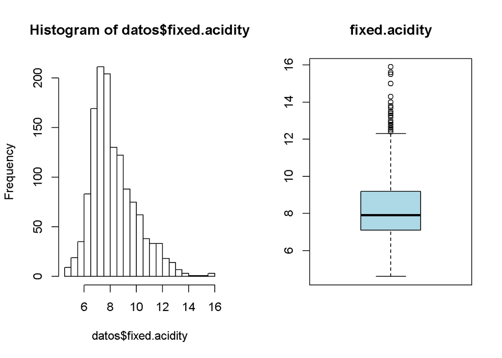

```r
par(mfrow=c(1,2))
hist(datos$fixed.acidity, breaks  = 30)
boxplot(datos$fixed.acidity,main="fixed.acidity", col="lightblue")
```

```r
boxplot.stats(datos$fixed.acidity)$out
```

```
##  [1] 12.8 15.0 12.5 13.3 13.4 12.4 12.5 13.8 13.5 12.6 12.5 12.8 14.0 13.7 12.7
## [16] 12.5 12.8 12.6 15.6 12.5 13.0 12.5 13.3 12.4 12.5 12.9 14.3 12.4 15.5 15.6
## [31] 13.0 12.7 12.4 12.7 13.2 13.2 15.9 13.3 12.9 12.6 12.6
```

Observamos como el atributo “fixed.acidity” tiene 41 valores extremos, distribuidos entre 12.4 y 16

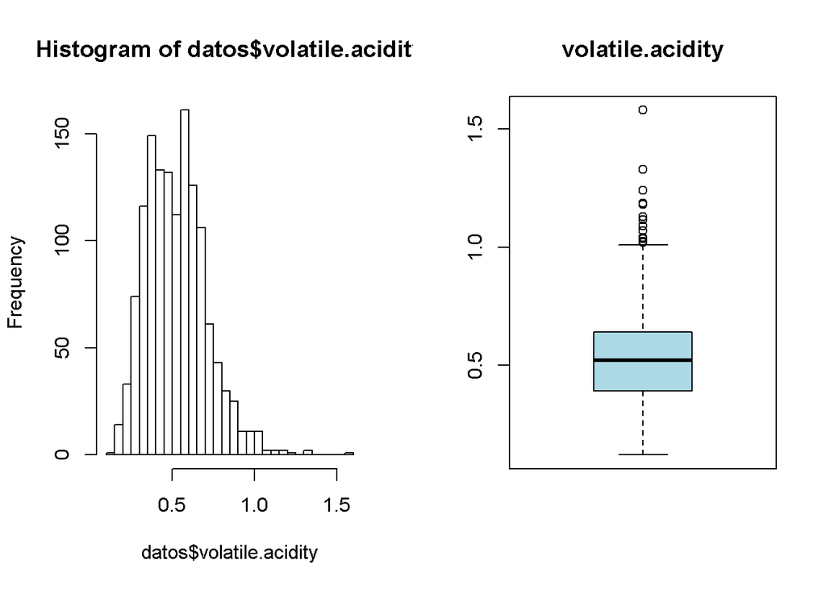

```r
par(mfrow=c(1,2))
hist(datos$volatile.acidity, breaks  = 30)
boxplot(datos$volatile.acidity,main="volatile.acidity", col="lightblue")
```

```r
boxplot.stats(datos$volatile.acidity)$out
```

```
##  [1] 1.130 1.020 1.070 1.330 1.330 1.040 1.090 1.040 1.240 1.185 1.020 1.035
## [13] 1.025 1.115 1.020 1.020 1.580 1.180 1.040
```

Observamos como el atributo “volatile.acidity” tiene 19 valores extremos, distribuidos entre 1 y 1.6

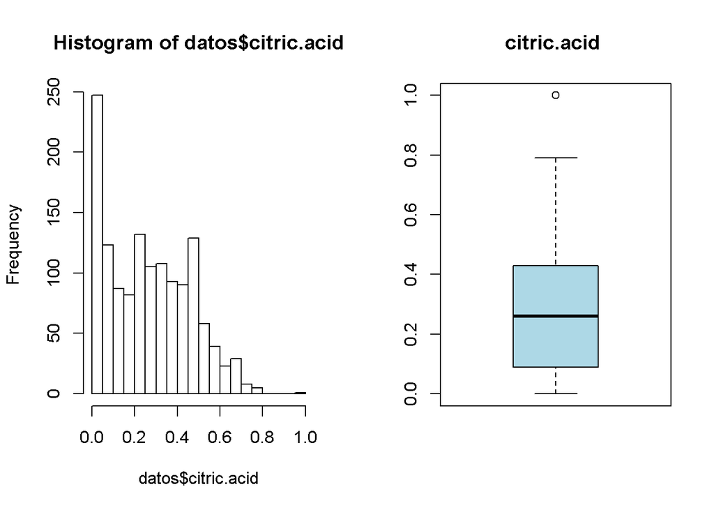

```r
par(mfrow=c(1,2))
hist(datos$citric.acid , breaks  = 30)
boxplot(datos$citric.acid ,main="citric.acid ", col="lightblue")
```

```r
boxplot.stats(datos$citric.acid )$out
```

```
## [1] 1
```

Observamos como el atributo “citric.acid” tiene un valor extremo de valor 1.

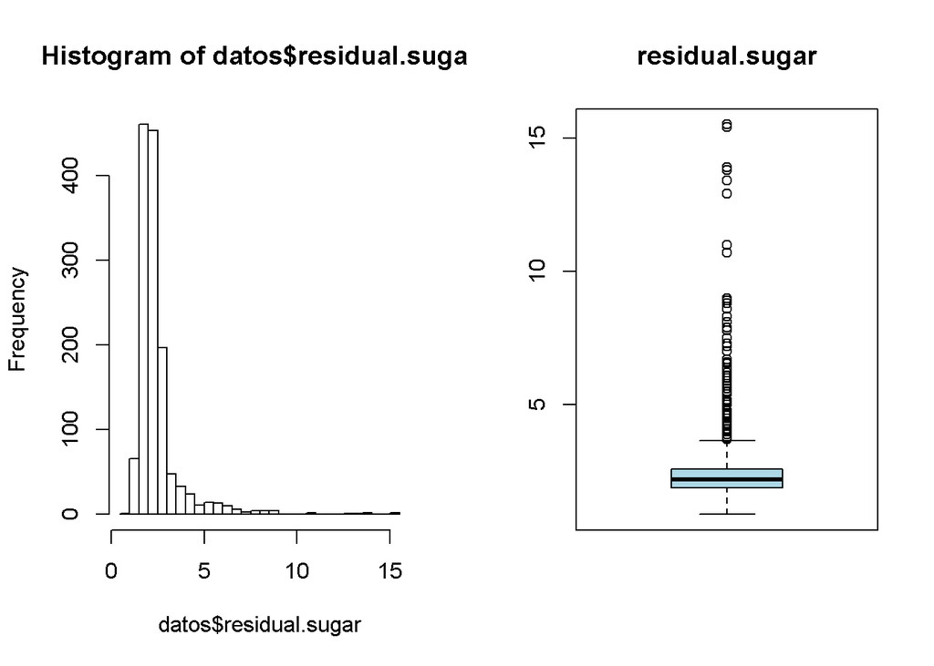

```r
par(mfrow=c(1,2))
hist(datos$residual.sugar, breaks  = 30)
boxplot(datos$residual.sugar,main="residual.sugar", col="lightblue")
```

```r
boxplot.stats(datos$residual.sugar)$out
```

```
##   [1]  6.10  3.80  3.90  4.40 10.70  5.50  5.90  3.80  5.10  4.65  5.50  5.50
##  [13]  7.30  7.20  3.80  5.60  4.00  4.00  4.00  7.00  6.40  5.60 11.00  4.50
##  [25]  4.80  5.80  3.80  4.40  6.20  4.20  7.90  3.70  4.50  6.70  6.60  3.70
##  [37]  5.20 15.50  4.10  8.30  6.55  4.60  6.10  4.30  5.80  5.15  6.30  4.20
##  [49]  4.60  4.20  4.30  7.90  4.60  5.10  5.60  6.00  8.60  7.50  4.40  4.25
##  [61]  6.00  3.90  4.20  4.00  4.00  6.60  6.00  3.80  9.00  4.60  8.80  5.00
##  [73]  3.80  4.10  5.90  4.10  6.20  8.90  4.00  3.90  8.10  6.40  8.30  8.30
##  [85]  4.70  5.50  4.30  5.50  3.70  6.20  5.60  7.80  4.60  5.80  4.10 12.90
##  [97]  4.30 13.40  4.80  6.30  4.50  4.30  3.90  3.80  5.40  3.80  6.10  3.90
## [109]  5.10  3.90 15.40  4.80  5.20  5.20  3.75 13.80  5.70  4.30  4.10  4.10
## [121]  4.40  3.70  6.70 13.90  5.10  7.80
```

Observamos como el atributo “residual.sugar” tiene 126 valores extremos, distribuidos entre 4 y 16

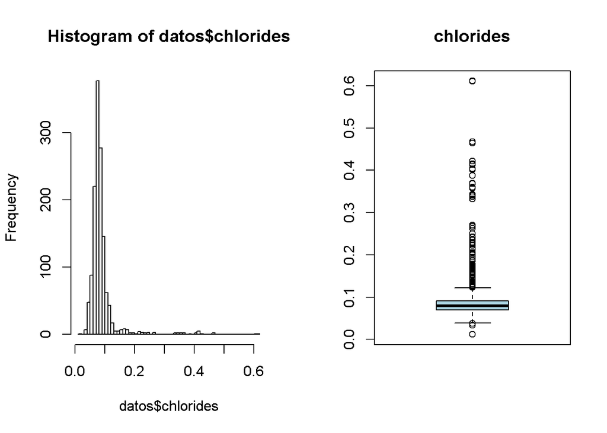

```r
par(mfrow=c(1,2))
hist(datos$chlorides, breaks  = 50)
boxplot(datos$chlorides,main="chlorides", col="lightblue")
```

```r
boxplot.stats(datos$chlorides)$out
```

```
##  [1] 0.176 0.170 0.368 0.341 0.172 0.332 0.464 0.401 0.467 0.178 0.146 0.236
## [13] 0.610 0.360 0.270 0.337 0.263 0.611 0.358 0.343 0.186 0.213 0.214 0.128
## [25] 0.159 0.124 0.174 0.127 0.413 0.152 0.152 0.125 0.200 0.171 0.226 0.250
## [37] 0.148 0.124 0.143 0.222 0.157 0.422 0.034 0.387 0.415 0.157 0.157 0.243
## [49] 0.241 0.190 0.132 0.126 0.038 0.165 0.145 0.147 0.012 0.194 0.132 0.161
## [61] 0.123 0.414 0.216 0.171 0.178 0.369 0.166 0.166 0.136 0.132 0.123 0.123
## [73] 0.403 0.137 0.414 0.166 0.168 0.415 0.153 0.267 0.123 0.214 0.169 0.205
## [85] 0.235 0.230 0.038
```

Observamos como el atributo “chlorides” tiene 87 valores extremos, distribuidos entre 0 y 0.05 por la parte inferior y entre 0.12 y 0.6 por la parte superior.

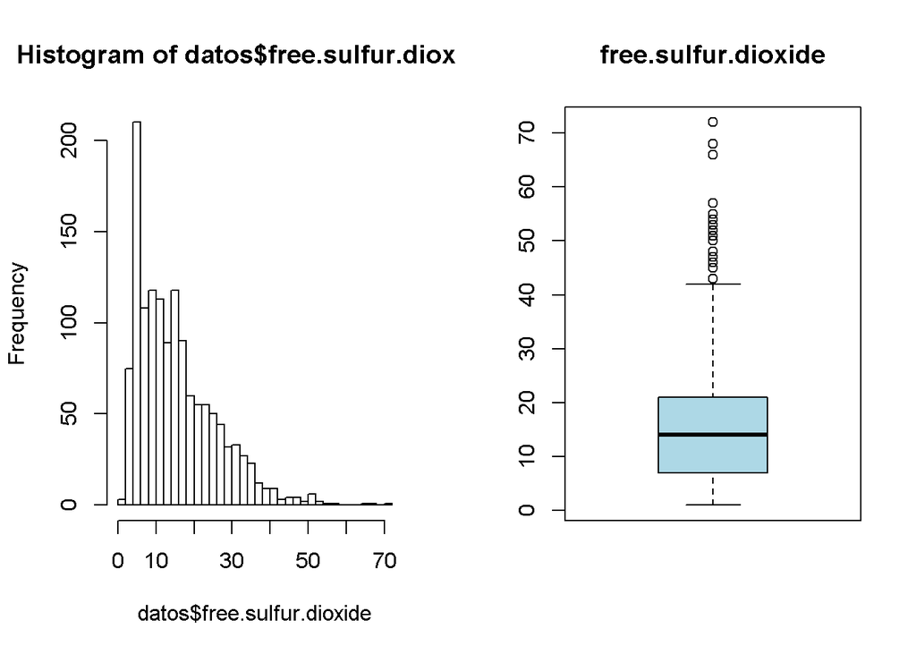

```r
par(mfrow=c(1,2))
hist(datos$free.sulfur.dioxide, breaks  = 30)
boxplot(datos$free.sulfur.dioxide,main="free.sulfur.dioxide", col="lightblue")
```

```r
boxplot.stats(datos$free.sulfur.dioxide)$out
```

```
##  [1] 52 51 50 68 43 47 54 46 45 53 52 51 45 57 50 45 48 43 48 72 43 51 52 55 48
## [26] 66
```

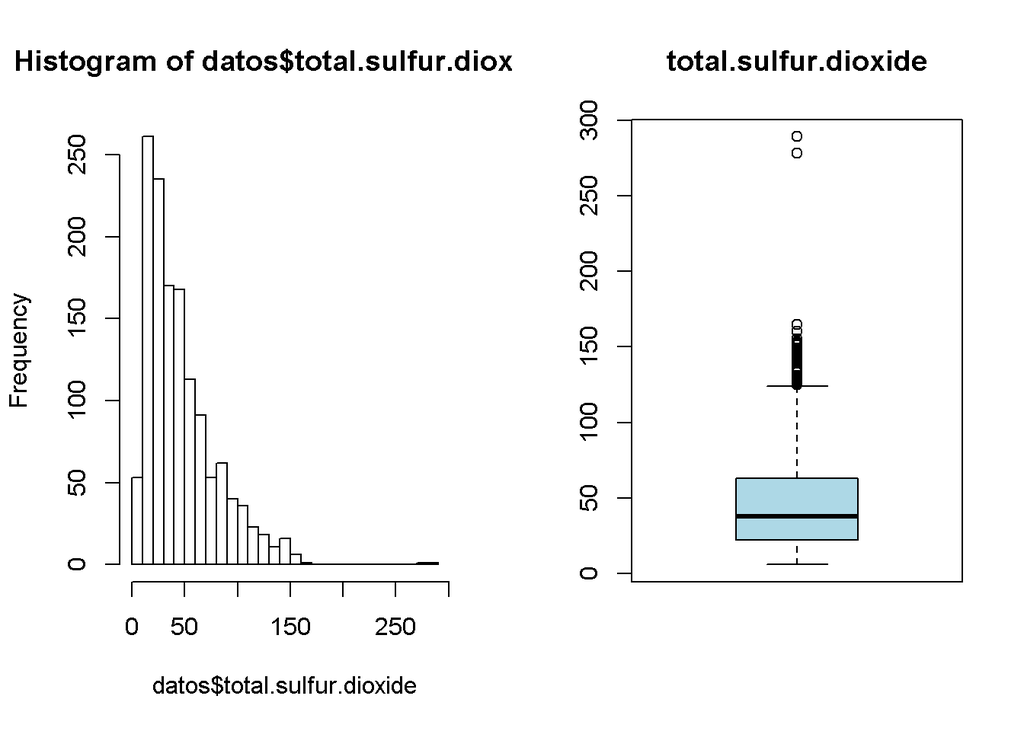

```r
par(mfrow=c(1,2))
hist(datos$total.sulfur.dioxide, breaks  = 30)
boxplot(datos$total.sulfur.dioxide,main="total.sulfur.dioxide", col="lightblue")
```

```r
boxplot.stats(datos$total.sulfur.dioxide)$out
```

```
##  [1] 145 148 136 125 140 133 153 134 141 129 128 143 144 127 126 145 144 135 165
## [20] 134 129 151 133 142 149 147 145 148 155 151 152 125 127 139 143 144 130 278
## [39] 289 135 160 141 133 147 131
```

Observamos como el atributo “total.sulfur.dioxide” tiene 45 valores extremos, distribuidos entre el 120 y el 300.

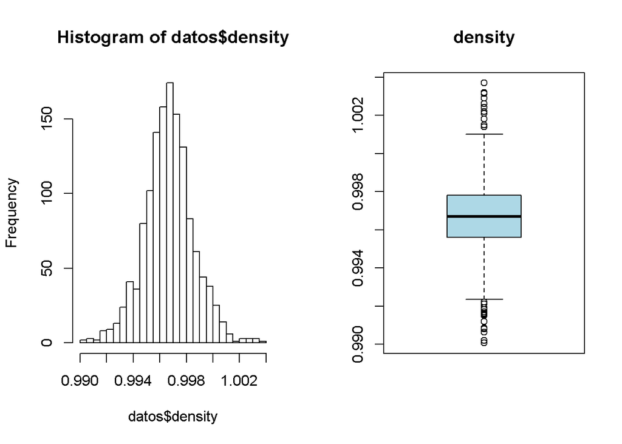

```r
par(mfrow=c(1,2))
hist(datos$density, breaks  = 30)
boxplot(datos$density,main="density", col="lightblue")
```

```r
boxplot.stats(datos$density)$out
```

```
##  [1] 0.99160 1.00140 1.00150 1.00180 0.99120 1.00220 1.00140 1.00140 1.00140
## [10] 1.00320 1.00260 1.00140 1.00315 1.00315 1.00210 0.99170 0.99220 1.00260
## [19] 0.99210 0.99154 0.99064 1.00289 0.99162 0.99007 0.99020 0.99220 0.99150
## [28] 0.99157 0.99080 0.99084 0.99191 1.00369 1.00242 0.99182 0.99182
```

Observamos como el atributo “density” tiene 35 valores extremos, distribuidos entre 0.990 y 0.992 por la parte inferior y entre 1.001 y 1.004 por la parte superior.

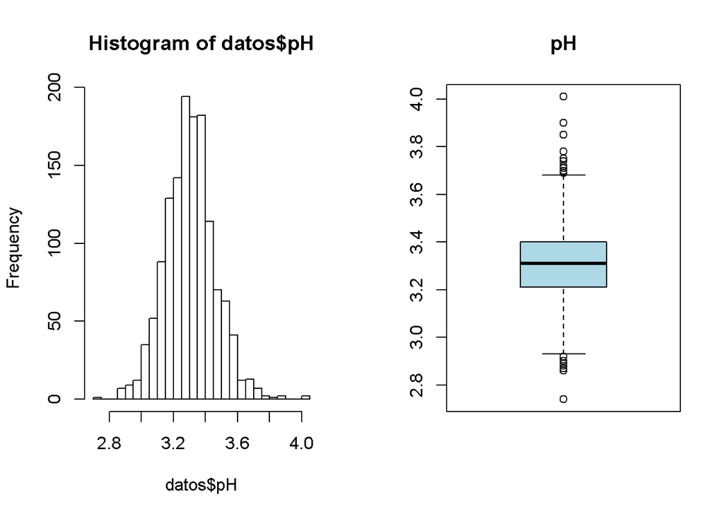

```r
par(mfrow=c(1,2))
hist(datos$pH, breaks  = 30)
boxplot(datos$pH,main="pH", col="lightblue")
```

```r
boxplot.stats(datos$pH)$out
```

```
##  [1] 3.90 3.75 3.85 2.74 3.69 2.88 2.86 3.74 2.92 2.92 3.72 2.87 2.89 2.92 3.90
## [16] 3.71 3.69 3.71 2.89 3.78 3.70 3.78 4.01 2.90 4.01 3.71 2.88 3.72
```

Observamos como el atributo “pH” tiene 28 valores extremos, distribuidos entre 2.7 y 2.9 por la parte inferior y entre 3.7 y 4 por la parte superior.

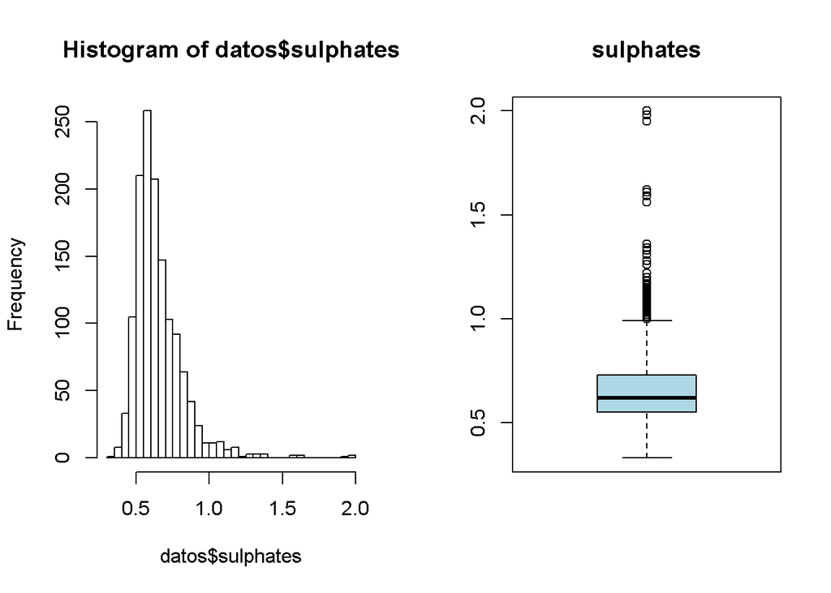

```r
par(mfrow=c(1,2))
hist(datos$sulphates, breaks  = 30)
boxplot(datos$sulphates,main="sulphates", col="lightblue")
```

```r
boxplot.stats(datos$sulphates)$out
```

```
##  [1] 1.56 1.28 1.08 1.20 1.12 1.28 1.14 1.95 1.22 1.98 1.31 2.00 1.08 1.59 1.02
## [16] 1.03 1.61 1.09 1.26 1.08 1.00 1.36 1.18 1.13 1.04 1.11 1.07 1.06 1.06 1.05
## [31] 1.06 1.04 1.05 1.02 1.14 1.02 1.36 1.36 1.05 1.17 1.62 1.06 1.18 1.07 1.34
## [46] 1.16 1.10 1.15 1.17 1.33 1.18 1.17 1.03 1.10 1.01
```

Observamos como el atributo “sulphates” tiene 55 valores extremos, distribuidos entre 1 y 2.

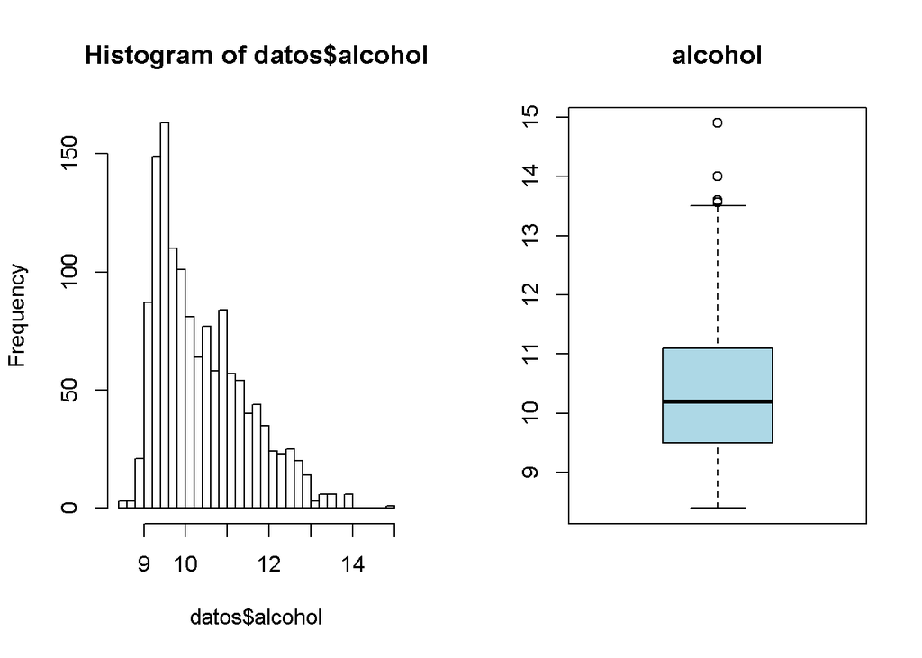

```r
par(mfrow=c(1,2))
hist(datos$alcohol, breaks  = 30)
boxplot(datos$alcohol,main="alcohol", col="lightblue")
```

```r
boxplot.stats(datos$alcohol)$out
```

```
##  [1] 14.00000 14.00000 14.00000 14.90000 14.00000 13.60000 13.60000 13.60000
##  [9] 14.00000 14.00000 13.56667 13.60000
```

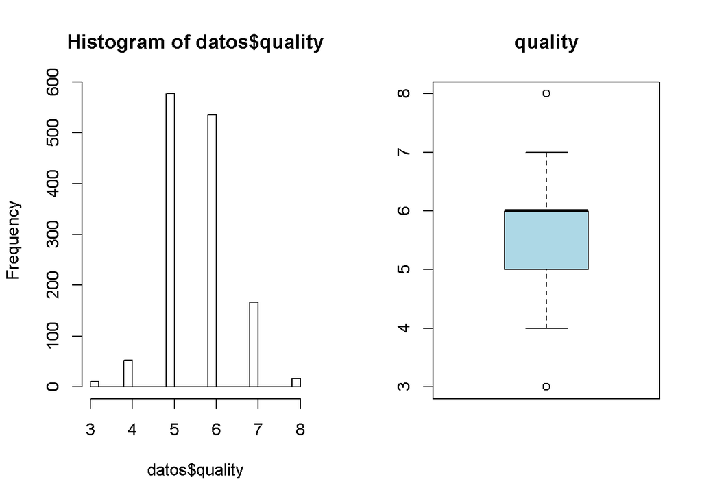

```r
par(mfrow=c(1,2))
hist(datos$quality, breaks  = 30)
boxplot(datos$quality,main="quality", col="lightblue")
```

```r
boxplot.stats(datos$quality)$out
```

```
##  [1] 8 8 8 8 8 3 8 8 3 8 3 8 3 3 8 8 8 8 8 3 3 8 8 3 3 3 8
```

Observamos como el atributo “quality” tiene 27 valores extremos, distribuidos entre el 3 por la parte inferior, y el 8 en la parte superior. Este valor es una valoración del vino, por lo que estos valores no se pueden considerar extremos.

En conclusión, con el análisis realizado para cada variable, el número de valores extremos es muy dispar, siendo bajo en algunas variables y relativamente alto en otras. Como es posible que algunos valores extremos de una variable coincidan en registro con los de otra, para identificar correctamente los valores extremos vamos a utilizar la distancia de Cook, estimando el grado de influencia de cada uno de los valores al realizar un análisis de regresión por mínimos cuadrados. Para realizarlo, tendremos en cuenta todos los atributos a excepción de “quality”.

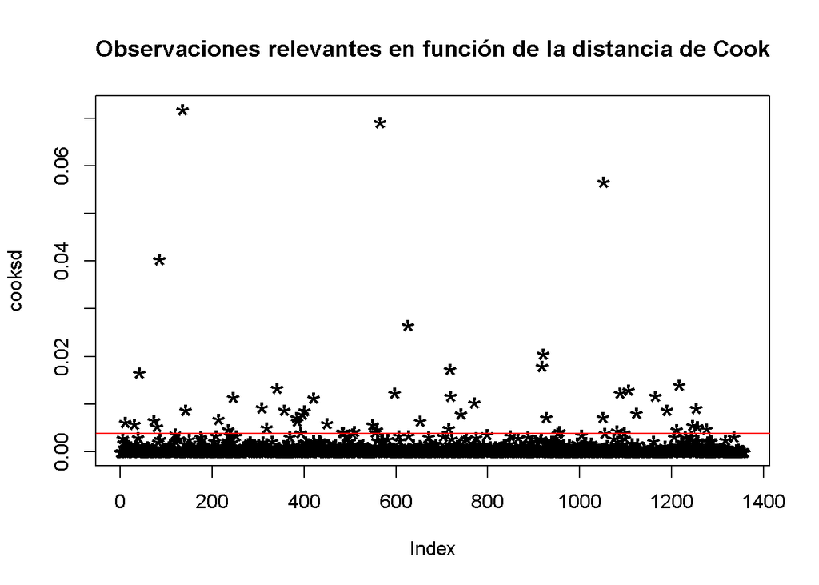

```r
# Cálculo y visualización de resultados de aplicar la distancia de Cook a nuestros datos.
outliers = c()
for ( i in 1:11 ) {
  stats = boxplot.stats(datos[[i]])$stats
  bottom_outlier_rows = which(datos[[i]] < stats[1])
  top_outlier_rows = which(datos[[i]] > stats[5])
  outliers = c(outliers , top_outlier_rows[ !top_outlier_rows %in% outliers ] )
  outliers = c(outliers , bottom_outlier_rows[ !bottom_outlier_rows %in% outliers ] )
}
mod = lm(quality ~ ., data = datos)
cooksd = cooks.distance(mod)
plot(cooksd, pch = "*", cex = 2, main = "Observaciones relevantes en función de la distancia de Cook")
abline(h = 4*mean(cooksd, na.rm = T), col = "red")
```

```r
# Obtenemos el listado de los valores extremos que afectan sensiblemente a los datos.
head(datos[cooksd > 4 * mean(cooksd, na.rm=T), ])
```

```
##    fixed.acidity volatile.acidity citric.acid residual.sugar chlorides
## 14           7.8            0.610        0.29            1.6     0.114
## 34           6.9            0.605        0.12           10.7     0.073
## 46           4.6            0.520        0.15            2.1     0.054
## 80           8.3            0.625        0.20            1.5     0.080
## 87           8.6            0.490        0.28            1.9     0.110
## 93           8.6            0.490        0.29            2.0     0.110
##    free.sulfur.dioxide total.sulfur.dioxide density   pH sulphates alcohol
## 14                   9                   29  0.9974 3.26      1.56     9.1
## 34                  40                   83  0.9993 3.45      0.52     9.4
## 46                   8                   65  0.9934 3.90      0.56    13.1
## 80                  27                  119  0.9972 3.16      1.12     9.1
## 87                  20                  136  0.9972 2.93      1.95     9.9
## 93                  19                  133  0.9972 2.93      1.98     9.8
##    quality
## 14       5
## 34       6
## 46       4
## 80       4
## 87       6
## 93       5
```

Vamos a eliminar los valores extremos detectados.

```r
# Identificamos los registros a eliminar
coutliers = as.numeric(rownames(datos[cooksd > 4 * mean(cooksd, na.rm=T), ]))
outliers = c(outliers , coutliers[ !coutliers %in% outliers ] )

# Eliminamos los elementos detectados como extremos.
datos_clean = datos[-outliers, ]

# Visualizamos el tamaño y los valores básicos de nuestro nuevo conjunto de datos.
dim(datos_clean)
```

```
## [1] 980  12
```

```r
summary(datos_clean)
```

```
##  fixed.acidity    volatile.acidity  citric.acid    residual.sugar
##  Min.   : 5.100   Min.   :0.1200   Min.   :0.000   Min.   :1.200
##  1st Qu.: 7.100   1st Qu.:0.3900   1st Qu.:0.080   1st Qu.:1.900
##  Median : 7.800   Median :0.5200   Median :0.240   Median :2.100
##  Mean   : 8.155   Mean   :0.5216   Mean   :0.249   Mean   :2.196
##  3rd Qu.: 9.000   3rd Qu.:0.6300   3rd Qu.:0.400   3rd Qu.:2.500
##  Max.   :12.300   Max.   :1.0100   Max.   :0.730   Max.   :3.650
##    chlorides       free.sulfur.dioxide total.sulfur.dioxide    density
##  Min.   :0.03900   Min.   : 1.00       Min.   :  6.00       Min.   :0.9923
##  1st Qu.:0.06900   1st Qu.: 8.00       1st Qu.: 22.00       1st Qu.:0.9955
##  Median :0.07800   Median :13.00       Median : 36.00       Median :0.9965
##  Mean   :0.07841   Mean   :15.01       Mean   : 42.38       Mean   :0.9965
##  3rd Qu.:0.08700   3rd Qu.:20.00       3rd Qu.: 56.00       3rd Qu.:0.9976
##  Max.   :0.12200   Max.   :42.00       Max.   :124.00       Max.   :1.0010
##        pH          sulphates         alcohol         quality
##  Min.   :2.940   Min.   :0.3700   Min.   : 8.70   Min.   :3.00
##  1st Qu.:3.230   1st Qu.:0.5500   1st Qu.: 9.50   1st Qu.:5.00
##  Median :3.320   Median :0.6100   Median :10.10   Median :6.00
##  Mean   :3.322   Mean   :0.6313   Mean   :10.39   Mean   :5.64
##  3rd Qu.:3.400   3rd Qu.:0.7000   3rd Qu.:11.00   3rd Qu.:6.00
##  Max.   :3.680   Max.   :0.9800   Max.   :13.40   Max.   :8.00
```

# 3 Análisis de los datos

Antes de comenzar con el análisis guardaremos una copia de los datos después del proceso de limpieza

```r
# Exportación de los datos limpios en .csv
write.csv(datos_clean, "winequality-red-clean.csv")
```

Analizaremos las variables frente a la calidad para decidir cuales utilizar en el resto del análisis

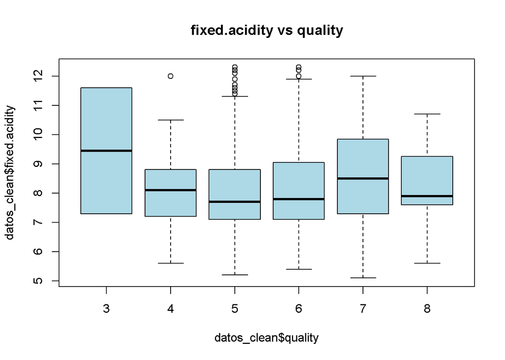

```r
#boxplot(datos$pH,main="quality", col="gray")
boxplot(formula = datos_clean$fixed.acidity ~ datos_clean$quality, main="fixed.acidity vs quality", col="lightblue")
```

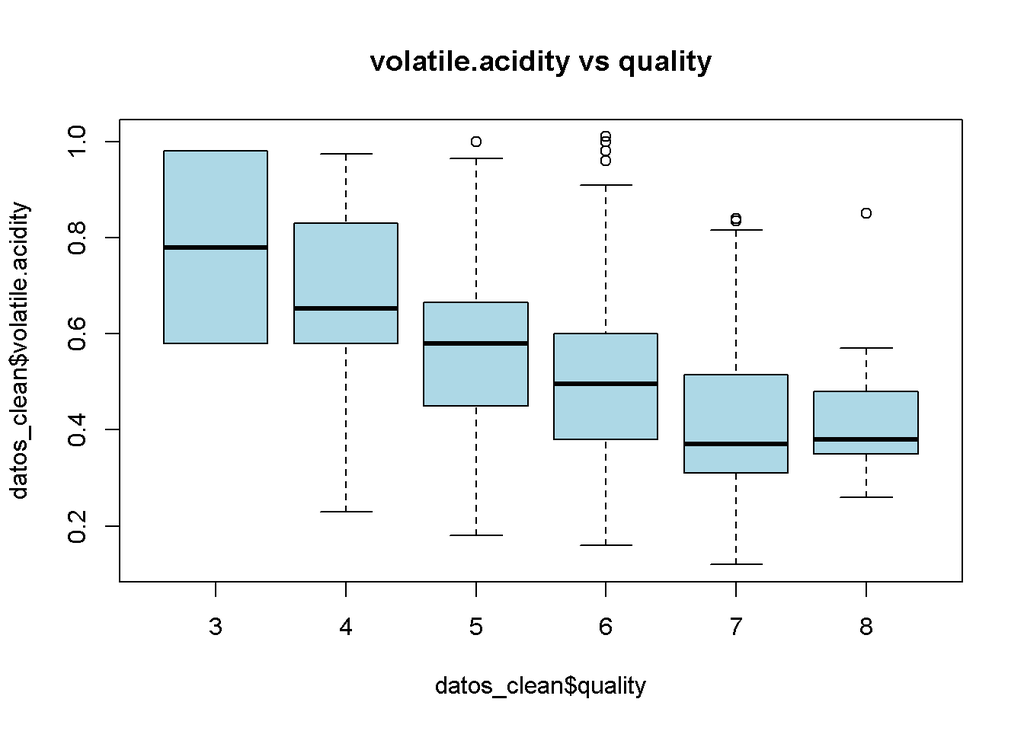

```r
boxplot(formula = datos_clean$volatile.acidity ~ datos_clean$quality, main="volatile.acidity vs quality", col="lightblue")
```

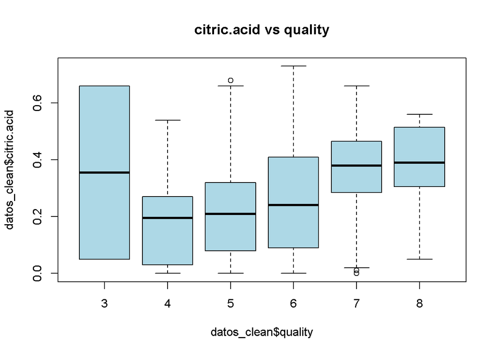

```r
boxplot(formula = datos_clean$citric.acid ~ datos_clean$quality, main="citric.acid vs quality", col="lightblue")
```

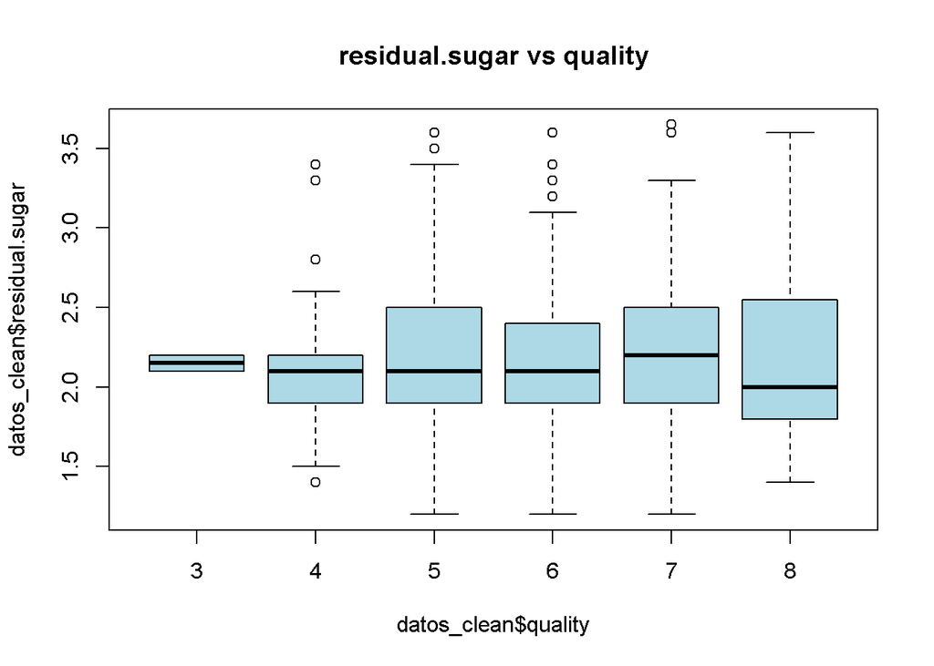

```r
boxplot(formula = datos_clean$residual.sugar ~ datos_clean$quality, main="residual.sugar vs quality", col="lightblue")
```

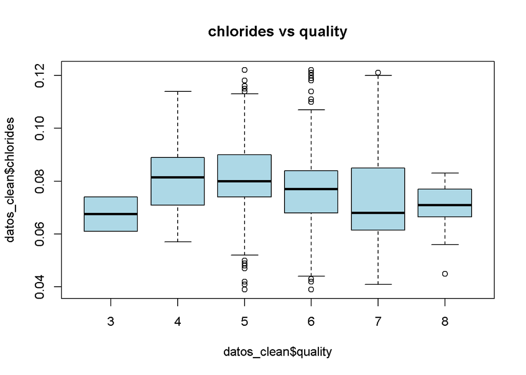

```r
boxplot(formula = datos_clean$chlorides ~ datos_clean$quality, main="chlorides vs quality", col="lightblue")
```

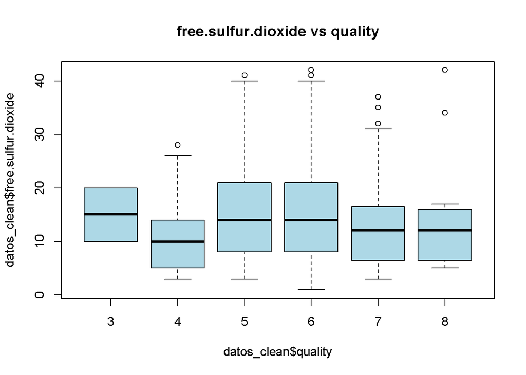

```r
boxplot(formula = datos_clean$free.sulfur.dioxide ~ datos_clean$quality, main="free.sulfur.dioxide vs quality", col="lightblue")
```

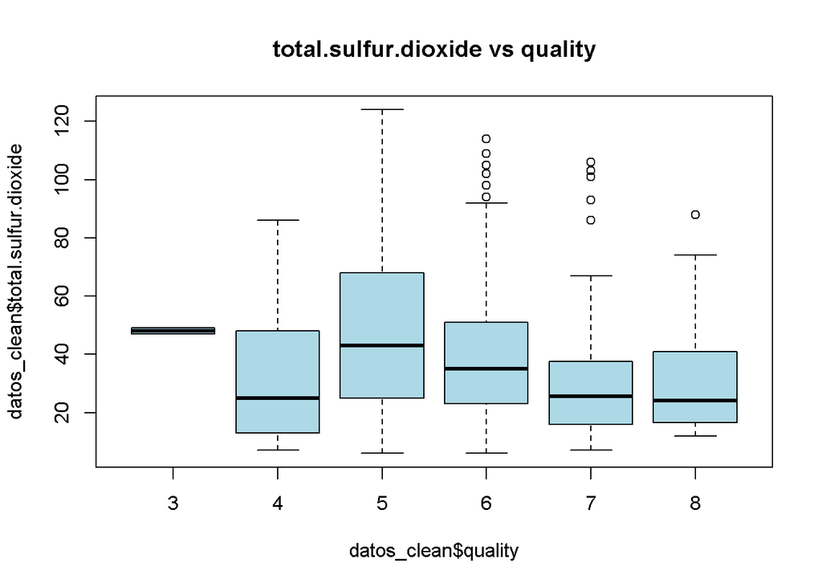

```r
boxplot(formula = datos_clean$total.sulfur.dioxide ~ datos_clean$quality, main="total.sulfur.dioxide vs quality", col="lightblue")
```

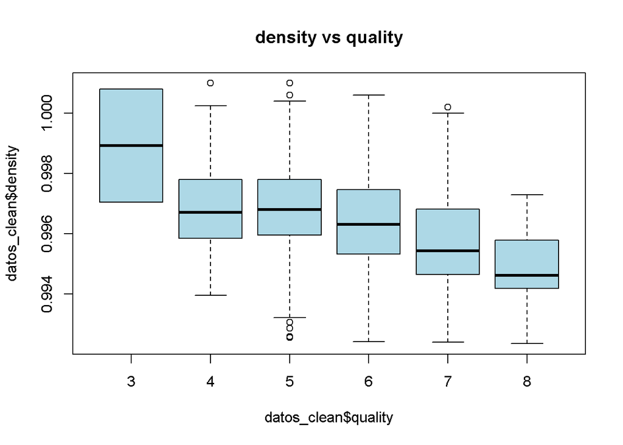

```r
boxplot(formula = datos_clean$density ~ datos_clean$quality, main="density vs quality", col="lightblue")
```

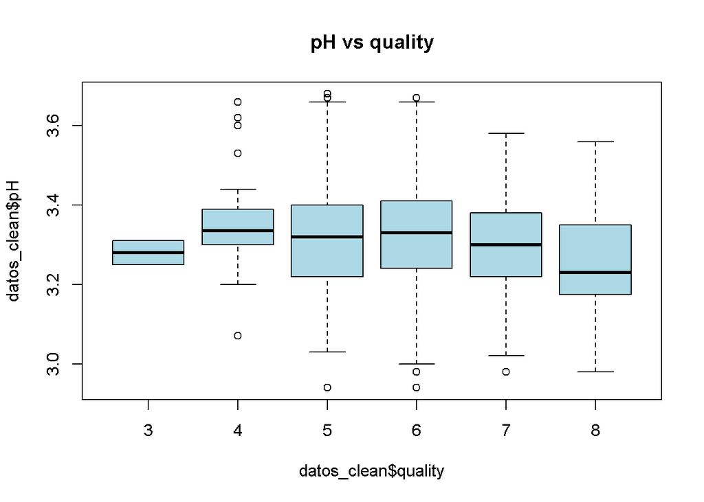

```r
boxplot(formula = datos_clean$pH ~ datos_clean$quality, main="pH vs quality", col="lightblue")
```

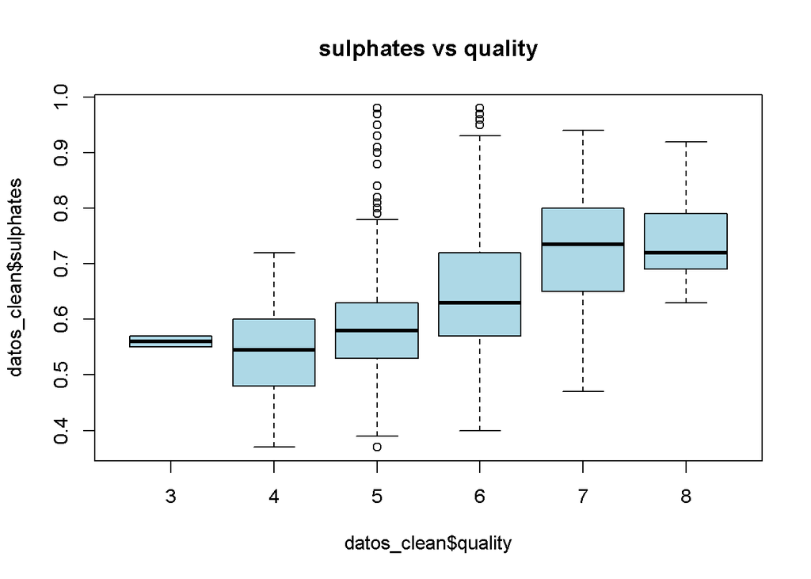

```r
boxplot(formula = datos_clean$sulphates ~ datos_clean$quality, main="sulphates vs quality", col="lightblue")
```

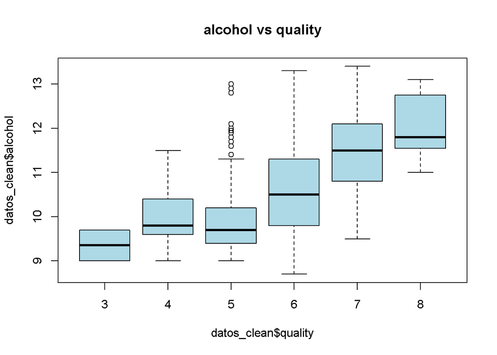

```r
boxplot(formula = datos_clean$alcohol ~ datos_clean$quality, main="alcohol vs quality", col="lightblue")
```

## Seleccion grupo de datos

```r
subdatos <- select(datos_clean, fixed.acidity, volatile.acidity, citric.acid, sulphates, alcohol)
```